# **NAME: SHAIK MOHID BABU**

# **REG. NO: 21BCE9569**

# **Branch: Computer Science and Engineering with Specialization in Artificial Intelligence and Machine Learning**

# **Campus: VIT-AP**

### **Email: mohidbabu.21bce9569@vitapstudent.ac.in**

### **Index:**

**1. Data Preprocessing**

```
   I) Import the Libraries.

   II) Importing the dataset.

   III) Checking for Null Values.

   IV) Data Visualization.

   V) Outlier Detection

   VI) Splitting Dependent and Independent variables

   VII) Perform Encoding

   VIII) Feature Scaling.

   XI) Splitting Data into Train and Test
```

**2. Logistic Regression**

```
   I) Evaluation Matrices
      i) Accuracy
      ii) classification Report
      iii) confusion matrix
      iv) ROC curve
```

**3. A Logistic Regression model was built on the dataset without applying scaling**

```
   I) Evaluation Matrices
      i) Accuracy
      ii) classification Report
      iii) confusion matrix
      iv) ROC curve
```

**4. HyperParameter Tuning on Logistic Regression**

```
   I) Evaluation Matrices
      i) Accuracy
      ii) classification Report
      iii) confusion matrix
      iv) ROC curve
```

**5. Decision Tree**

```
  I) Evaluation Matrices
     i) Accuracy
     ii) classification Report
     iii) confusion matrix
     iv) ROC curve
```

**6. HyperParameter Tuning on Decision Tree**

```
   I) Evaluation Matrices
      i) Accuracy
      ii) classification Report
      iii) confusion matrix
      iv) ROC curve
```

**7. Random Forest**

```
  I) Evaluation Matrices
      i) Accuracy
      ii) classification Report
      iii) confusion matrix
      iv) ROC curve
```

**8. HyperParameter Tuning on Random Forest**

```
  I) Evaluation Matrices
      i) Accuracy
      ii) classification Report
      iii) confusion matrix
      iv) ROC curve
```

1.Download the Employee Attrition Dataset https://www.kaggle.com/datasets/patelprashant/employee-attrition

2.Perfrom Data Preprocessing

3.Model Building using Logistic Regression and Decision Tree

4.Calculate Performance metrics

# Data Preprocessing

Data Preprocessing o Import the Libraries. o Importing the dataset. o Checking for Null Values. o Data Visualization. o Outlier Detection o Splitting Dependent and Independent variables o Perform Encoding o Feature Scaling. o Splitting Data into Train and Test

### 1. Import the Libraries.

```python
import numpy as np
import pandas as pd
import matplotlib.pyplot as plt
import seaborn as sns
from sklearn.preprocessing import MinMaxScaler
from sklearn.model_selection import train_test_split
```

### 2. Importing the dataset.

```python
df=pd.read_csv("WA_Fn-UseC_-HR-Employee-Attrition.csv")
```

```python
df.head()
```

|  | Age | Attrition | BusinessTravel | DailyRate | Department | DistanceFromHome | Education | EducationField | EmployeeCount | EmployeeNumber | ... | RelationshipSatisfaction | StandardHours | StockOptionLevel | TotalWorkingYears | TrainingTimesLastYear | WorkLifeBalance | YearsAtCompany | YearsInCurrentRole | YearsSinceLastPromotion | YearsWithCurrManager |
| --- | --- | --- | --- | --- | --- | --- | --- | --- | --- | --- | --- | --- | --- | --- | --- | --- | --- | --- | --- | --- | --- |
| 0 | 41 | Yes | Travel_Rarely | 1102 | Sales | 1 | 2 | Life Sciences | 1 | 1 | ... | 1 | 80 | 0 | 8 | 0 | 1 | 6 | 4 | 0 | 5 |
| 1 | 49 | No | Travel_Frequently | 279 | Research & Development | 8 | 1 | Life Sciences | 1 | 2 | ... | 4 | 80 | 1 | 10 | 3 | 3 | 10 | 7 | 1 | 7 |
| 2 | 37 | Yes | Travel_Rarely | 1373 | Research & Development | 2 | 2 | Other | 1 | 4 | ... | 2 | 80 | 0 | 7 | 3 | 3 | 0 | 0 | 0 | 0 |
| 3 | 33 | No | Travel_Frequently | 1392 | Research & Development | 3 | 4 | Life Sciences | 1 | 5 | ... | 3 | 80 | 0 | 8 | 3 | 3 | 8 | 7 | 3 | 0 |
| 4 | 27 | No | Travel_Rarely | 591 | Research & Development | 2 | 1 | Medical | 1 | 7 | ... | 4 | 80 | 1 | 6 | 3 | 3 | 2 | 2 | 2 | 2 |

5 rows × 35 columns

DataSet Discription Education 1.'Below College' 2 'College' 3 'Bachelor' 4 'Master' 5 'Doctor' EnvironmentSatisfaction 1 'Low' 2 'Medium' 3 'High' 4 'Very High' JobInvolvement 1 'Low' 2 'Medium' 3 'High' 4 'Very High' JobSatisfaction 1 'Low' 2 'Medium' 3 'High' 4 'Very High' PerformanceRating 1 'Low' 2 'Good' 3 'Excellent' 4 'Outstanding' RelationshipSatisfaction 1 'Low' 2 'Medium' 3 'High' 4 'Very High' WorkLifeBalance 1 'Bad' 2 'Good' 3 'Better' 4 'Best'

```python
df.EnvironmentSatisfaction
```

```
0       2
1       3
2       4
3       4
4       1
       ..
1465    3
1466    4
1467    2
1468    4
1469    2
Name: EnvironmentSatisfaction, Length: 1470, dtype: int64
```

```python
df.JobRole.unique()
```

```
array(['Sales Executive', 'Research Scientist', 'Laboratory Technician',
       'Manufacturing Director', 'Healthcare Representative', 'Manager',
       'Sales Representative', 'Research Director', 'Human Resources'],
      dtype=object)
```

```python
df.info()
```

```
<class 'pandas.core.frame.DataFrame'>
RangeIndex: 1470 entries, 0 to 1469
Data columns (total 35 columns):
 #   Column                    Non-Null Count  Dtype
---  ------                    --------------  -----
 0   Age                       1470 non-null   int64
 1   Attrition                 1470 non-null   object
 2   BusinessTravel            1470 non-null   object
 3   DailyRate                 1470 non-null   int64
 4   Department                1470 non-null   object
 5   DistanceFromHome          1470 non-null   int64
 6   Education                 1470 non-null   int64
 7   EducationField            1470 non-null   object
 8   EmployeeCount             1470 non-null   int64
 9   EmployeeNumber            1470 non-null   int64
```

[output cut: 27 more lines]

```python
df.BusinessTravel.unique()
```

```
array(['Travel_Rarely', 'Travel_Frequently', 'Non-Travel'], dtype=object)
```

```python
df.Department.unique()
```

```
array(['Sales', 'Research & Development', 'Human Resources'], dtype=object)
```

```python
df.EducationField.unique()
```

```
array(['Life Sciences', 'Other', 'Medical', 'Marketing',
       'Technical Degree', 'Human Resources'], dtype=object)
```

```python
df.JobRole.unique()
```

```
array(['Sales Executive', 'Research Scientist', 'Laboratory Technician',
       'Manufacturing Director', 'Healthcare Representative', 'Manager',
       'Sales Representative', 'Research Director', 'Human Resources'],
      dtype=object)
```

```python
df.MaritalStatus.unique()
```

```
array(['Single', 'Married', 'Divorced'], dtype=object)
```

```python
df.Over18.unique()
```

```
array(['Y'], dtype=object)
```

```python
df.OverTime.unique()
```

```
array(['Yes', 'No'], dtype=object)
```

```python
for column in df.columns:
    print(f"{column}: Number of unique values ={df[column].nunique()}")
    print()
```

```
Age: Number of unique values =43

Attrition: Number of unique values =2

BusinessTravel: Number of unique values =3

DailyRate: Number of unique values =886

Department: Number of unique values =3

DistanceFromHome: Number of unique values =29

Education: Number of unique values =5

EducationField: Number of unique values =6

EmployeeCount: Number of unique values =1

EmployeeNumber: Number of unique values =1470

EnvironmentSatisfaction: Number of unique values =4

Gender: Number of unique values =2

HourlyRate: Number of unique values =71

JobInvolvement: Number of unique values =4

JobLevel: Number of unique values =5

JobRole: Number of unique values =9

JobSatisfaction: Number of unique values =4

MaritalStatus: Number of unique values =3

MonthlyIncome: Number of unique values =1349

MonthlyRate: Number of unique values =1427

```

[output cut: 14 more lines]

```
StockOptionLevel: Number of unique values =4

TotalWorkingYears: Number of unique values =40

TrainingTimesLastYear: Number of unique values =7

WorkLifeBalance: Number of unique values =4

YearsAtCompany: Number of unique values =37

YearsInCurrentRole: Number of unique values =19

YearsSinceLastPromotion: Number of unique values =16

YearsWithCurrManager: Number of unique values =18
```

### 3. Checking for Null Values.

```python
df.isnull().any()
```

```
Age                         False
Attrition                   False
BusinessTravel              False
DailyRate                   False
Department                  False
DistanceFromHome            False
Education                   False
EducationField              False
EmployeeCount               False
EmployeeNumber              False
EnvironmentSatisfaction     False
Gender                      False
HourlyRate                  False
JobInvolvement              False
JobLevel                    False
JobRole                     False
JobSatisfaction             False
MaritalStatus               False
MonthlyIncome               False
MonthlyRate                 False
NumCompaniesWorked          False
Over18                      False
OverTime                    False
PercentSalaryHike           False
PerformanceRating           False
RelationshipSatisfaction    False
StandardHours               False
StockOptionLevel            False
TotalWorkingYears           False
TrainingTimesLastYear       False
WorkLifeBalance             False
YearsAtCompany              False
YearsInCurrentRole          False
YearsSinceLastPromotion     False
YearsWithCurrManager        False
dtype: bool
```

```python
df.isnull().sum()
```

```
Age                         0
Attrition                   0
BusinessTravel              0
DailyRate                   0
Department                  0
DistanceFromHome            0
Education                   0
EducationField              0
EmployeeCount               0
EmployeeNumber              0
EnvironmentSatisfaction     0
Gender                      0
HourlyRate                  0
JobInvolvement              0
JobLevel                    0
JobRole                     0
JobSatisfaction             0
MaritalStatus               0
MonthlyIncome               0
MonthlyRate                 0
NumCompaniesWorked          0
Over18                      0
OverTime                    0
PercentSalaryHike           0
PerformanceRating           0
RelationshipSatisfaction    0
StandardHours               0
StockOptionLevel            0
TotalWorkingYears           0
TrainingTimesLastYear       0
WorkLifeBalance             0
YearsAtCompany              0
YearsInCurrentRole          0
YearsSinceLastPromotion     0
YearsWithCurrManager        0
dtype: int64
```

### The dataset does not contain any null values.

### 4. Data Visualization.

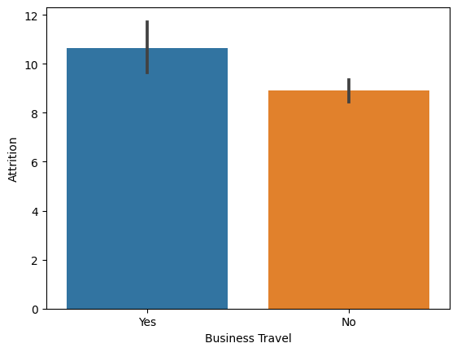

```python
sns.barplot(x="Attrition",y="DistanceFromHome",data=df)
plt.xlabel("Business Travel")
plt.ylabel("Attrition")
```

Inference: It is highly probable that employees who were distant from the office are more likely to experience attrition

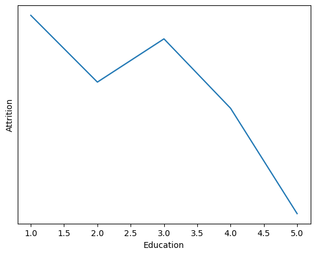

```python
sns.lineplot(x="Education",y="Attrition",data=df,ci=0)
```

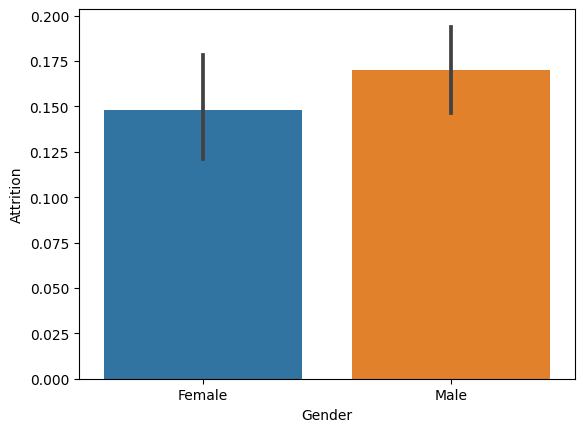

```python
df['Attrition'] = df['Attrition'].map({'Yes': 1, 'No': 0})
sns.barplot(x="Gender", y="Attrition", data=df)
```

Inference: Male employees are more prone to experiencing attrition.

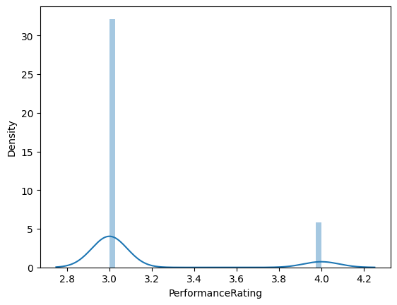

```python
sns.distplot(df.PerformanceRating)
```

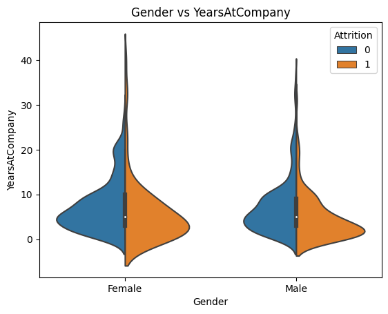

```python
plt.title("Gender vs YearsAtCompany")
sns.violinplot(x="Gender",y="YearsAtCompany",hue="Attrition",split=True,data=df)
```

```python
df.Attrition.value_counts()
```

```
0    1233
1     237
Name: Attrition, dtype: int64
```

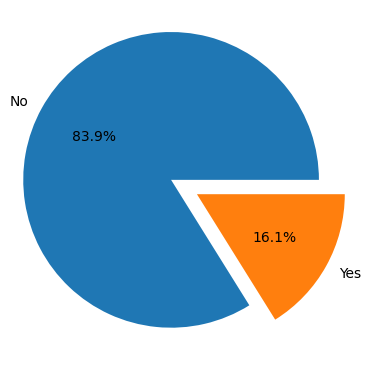

```python
labels=["No","Yes"]
plt.pie(df.Attrition.value_counts(),labels=labels,autopct='%1.1f%%',explode=(0.2,0))
plt.show()
```

```python
corr_matrix=df.select_dtypes(include=['number']).corr()
```

```python
print(type(corr_matrix))
```

```
<class 'pandas.core.frame.DataFrame'>
```

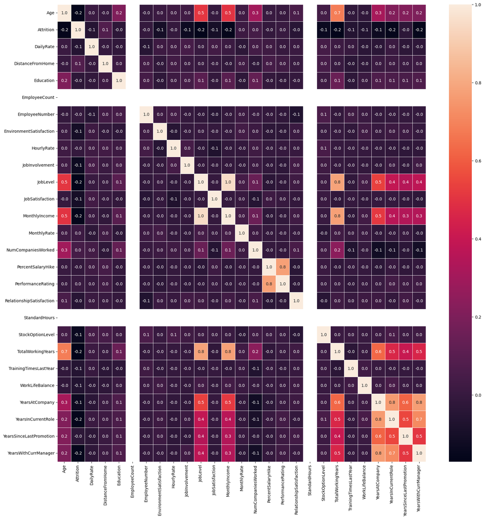

```python
f,ax = plt.subplots(figsize=(20, 20))
sns.heatmap(corr_matrix, annot=True, linewidths=.5, fmt= '.1f',ax=ax)
```

# 5. Outlier Detection

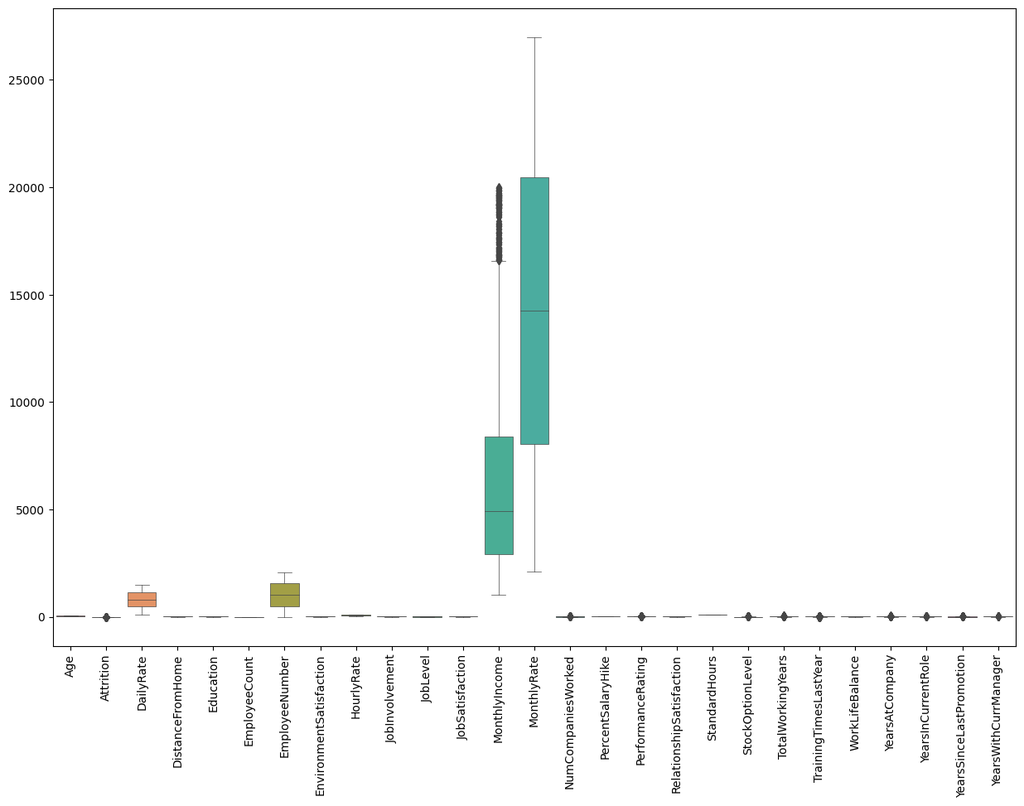

```python
f, ax = plt.subplots(figsize=(15, 10))
sns.boxplot(data=df, linewidth=0.5, fliersize=5, ax=ax)
plt.xticks(rotation=90)
plt.show()
```

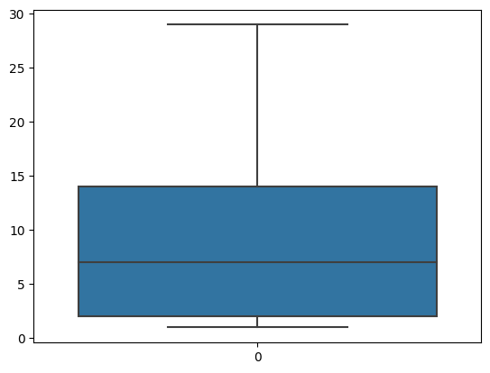

```python
sns.boxplot(df.DistanceFromHome)
```

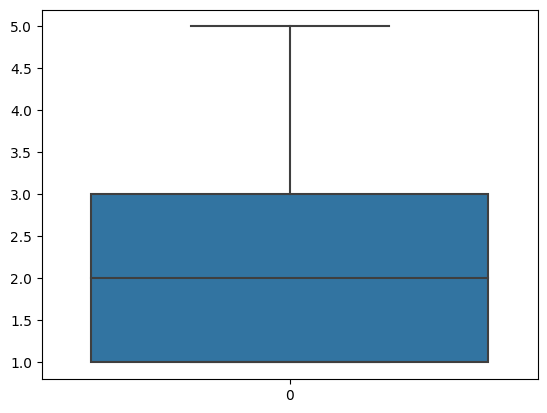

```python
sns.boxplot(df.JobLevel)
```

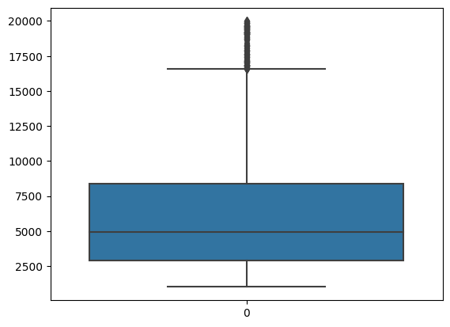

```python
sns.boxplot(df.MonthlyIncome)
```

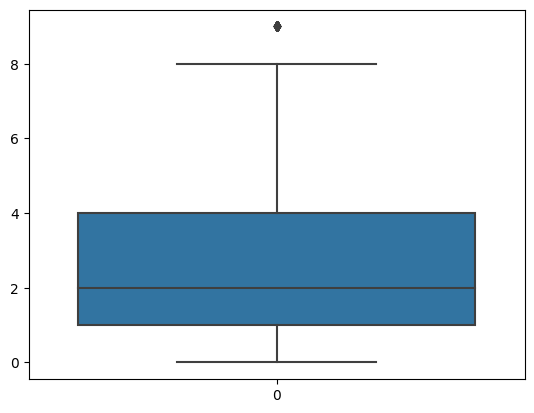

```python
sns.boxplot(df.NumCompaniesWorked)
```

```python
q1=df.NumCompaniesWorked.quantile(0.25)
q3=df.NumCompaniesWorked.quantile(0.75)
print(q1)
print(q3)
```

```
1.0
4.0
```

```python
IQR=q3-q1
print(IQR)
```

```
3.0
```

```python
upper_limit = q3+1.5*IQR
upper_limit
```

```
8.5
```

```python
df.NumCompaniesWorked.median()
```

```
2.0
```

```python
df.NumCompaniesWorked=np.where(df.NumCompaniesWorked>upper_limit,2,df.NumCompaniesWorked)
```

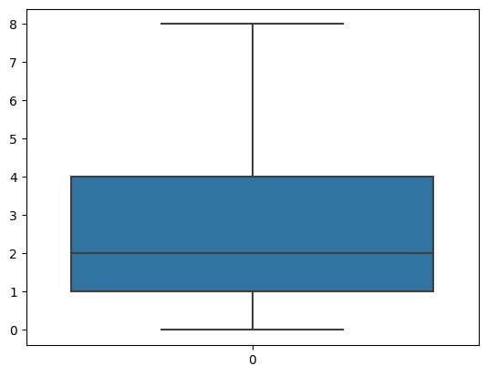

```python
sns.boxplot(df.NumCompaniesWorked)
```

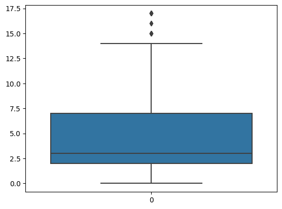

```python
sns.boxplot(df.YearsWithCurrManager)
```

```python
q1=df.YearsWithCurrManager.quantile(0.25)
q3=df.YearsWithCurrManager.quantile(0.75)
print(q1)
print(q3)
```

```
2.0
7.0
```

```python
IQR=q3-q1
IQR
```

```
5.0
```

```python
upper_limit=q3+1.5*IQR
upper_limit
```

```
14.5
```

```python
df.YearsWithCurrManager.median()
```

```
3.0
```

```python
df.YearsWithCurrManager=np.where(df.YearsWithCurrManager>upper_limit,3,df.YearsWithCurrManager)
```

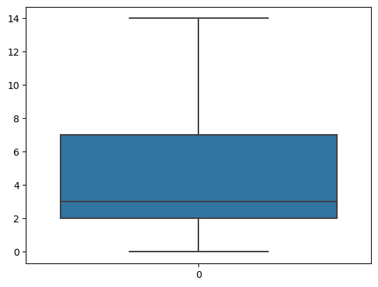

```python
sns.boxplot(df.YearsWithCurrManager)
```

```python
df.PerformanceRating.unique()
```

```
array([3, 4])
```

The columns "YearsAtCompany," "PerformanceRating," and "MonthlyIncome" are critical in the dataset, and there is no requirement to address outliers in these columns.

# 6. Splitting Dependent and Independent variables

```python
x=df.drop(["Attrition","Over18","EmployeeCount","StandardHours","EmployeeNumber"],axis=1)
x.info()
```

```
<class 'pandas.core.frame.DataFrame'>
RangeIndex: 1470 entries, 0 to 1469
Data columns (total 30 columns):
 #   Column                    Non-Null Count  Dtype
---  ------                    --------------  -----
 0   Age                       1470 non-null   int64
 1   BusinessTravel            1470 non-null   object
 2   DailyRate                 1470 non-null   int64
 3   Department                1470 non-null   object
 4   DistanceFromHome          1470 non-null   int64
 5   Education                 1470 non-null   int64
 6   EducationField            1470 non-null   object
 7   EnvironmentSatisfaction   1470 non-null   int64
 8   Gender                    1470 non-null   object
 9   HourlyRate                1470 non-null   int64
```

[output cut: 22 more lines]

```python
y=df.Attrition
print(y)
type(y)
```

```
0       1
1       0
2       1
3       0
4       0
       ..
1465    0
1466    0
1467    0
1468    0
1469    0
Name: Attrition, Length: 1470, dtype: int64
```

```
pandas.core.series.Series
```

# 7.Encoding

```python
from sklearn.preprocessing import LabelEncoder
from sklearn.preprocessing import OrdinalEncoder
```

```python
le=LabelEncoder()
oe=OrdinalEncoder()
```

```python
y=le.fit_transform(y)
y
```

```
array([1, 0, 1, ..., 0, 0, 0])
```

```python
x["Gender"]=le.fit_transform(x["Gender"])
x["Gender"]
```

```
0       0
1       1
2       1
3       0
4       1
       ..
1465    1
1466    1
1467    1
1468    1
1469    1
Name: Gender, Length: 1470, dtype: int64
```

```python
x["OverTime"]=le.fit_transform(x["OverTime"])
x["OverTime"]
```

```
0       1
1       0
2       1
3       1
4       0
       ..
1465    0
1466    0
1467    1
1468    0
1469    0
Name: OverTime, Length: 1470, dtype: int64
```

```python
custom_order = ["Non-Travel","Travel_Rarely","Travel_Frequently"]

# Create an instance of OrdinalEncoder with custom categories
encoder = OrdinalEncoder(categories=[custom_order])

# Fit and transform the "BusinessTravel" column
x["BusinessTravel"] = encoder.fit_transform(x[["BusinessTravel"]])
```

```python
x.BusinessTravel
```

```
0       1.0
1       2.0
2       1.0
3       2.0
4       1.0
       ...
1465    2.0
1466    1.0
1467    1.0
1468    2.0
1469    1.0
Name: BusinessTravel, Length: 1470, dtype: float64
```

```python
Department = pd.get_dummies(x["Department"], drop_first=True).astype(int)
x=pd.concat([x,Department],axis=1)
x.drop(["Department"],axis=1,inplace=True)
```

```python
x.info()
```

```
<class 'pandas.core.frame.DataFrame'>
RangeIndex: 1470 entries, 0 to 1469
Data columns (total 31 columns):
 #   Column                    Non-Null Count  Dtype
---  ------                    --------------  -----
 0   Age                       1470 non-null   int64
 1   BusinessTravel            1470 non-null   float64
 2   DailyRate                 1470 non-null   int64
 3   DistanceFromHome          1470 non-null   int64
 4   Education                 1470 non-null   int64
 5   EducationField            1470 non-null   object
 6   EnvironmentSatisfaction   1470 non-null   int64
 7   Gender                    1470 non-null   int64
 8   HourlyRate                1470 non-null   int64
 9   JobInvolvement            1470 non-null   int64
```

[output cut: 23 more lines]

```python
MaritalStatus = pd.get_dummies(x["MaritalStatus"], drop_first=True).astype(int)
x=pd.concat([x,MaritalStatus],axis=1)
x.drop(["MaritalStatus"],axis=1,inplace=True)
x
```

|  | Age | BusinessTravel | DailyRate | DistanceFromHome | Education | EducationField | EnvironmentSatisfaction | Gender | HourlyRate | JobInvolvement | ... | TrainingTimesLastYear | WorkLifeBalance | YearsAtCompany | YearsInCurrentRole | YearsSinceLastPromotion | YearsWithCurrManager | Research & Development | Sales | Married | Single |
| --- | --- | --- | --- | --- | --- | --- | --- | --- | --- | --- | --- | --- | --- | --- | --- | --- | --- | --- | --- | --- | --- |
| 0 | 41 | 1.0 | 1102 | 1 | 2 | Life Sciences | 2 | 0 | 94 | 3 | ... | 0 | 1 | 6 | 4 | 0 | 5 | 0 | 1 | 0 | 1 |
| 1 | 49 | 2.0 | 279 | 8 | 1 | Life Sciences | 3 | 1 | 61 | 2 | ... | 3 | 3 | 10 | 7 | 1 | 7 | 1 | 0 | 1 | 0 |
| 2 | 37 | 1.0 | 1373 | 2 | 2 | Other | 4 | 1 | 92 | 2 | ... | 3 | 3 | 0 | 0 | 0 | 0 | 1 | 0 | 0 | 1 |
| 3 | 33 | 2.0 | 1392 | 3 | 4 | Life Sciences | 4 | 0 | 56 | 3 | ... | 3 | 3 | 8 | 7 | 3 | 0 | 1 | 0 | 1 | 0 |
| 4 | 27 | 1.0 | 591 | 2 | 1 | Medical | 1 | 1 | 40 | 3 | ... | 3 | 3 | 2 | 2 | 2 | 2 | 1 | 0 | 1 | 0 |
| ... | ... | ... | ... | ... | ... | ... | ... | ... | ... | ... | ... | ... | ... | ... | ... | ... | ... | ... | ... | ... | ... |
| 1465 | 36 | 2.0 | 884 | 23 | 2 | Medical | 3 | 1 | 41 | 4 | ... | 3 | 3 | 5 | 2 | 0 | 3 | 1 | 0 | 1 | 0 |
| 1466 | 39 | 1.0 | 613 | 6 | 1 | Medical | 4 | 1 | 42 | 2 | ... | 5 | 3 | 7 | 7 | 1 | 7 | 1 | 0 | 1 | 0 |
| 1467 | 27 | 1.0 | 155 | 4 | 3 | Life Sciences | 2 | 1 | 87 | 4 | ... | 0 | 3 | 6 | 2 | 0 | 3 | 1 | 0 | 1 | 0 |
| 1468 | 49 | 2.0 | 1023 | 2 | 3 | Medical | 4 | 1 | 63 | 2 | ... | 3 | 2 | 9 | 6 | 0 | 8 | 0 | 1 | 1 | 0 |
| 1469 | 34 | 1.0 | 628 | 8 | 3 | Medical | 2 | 1 | 82 | 4 | ... | 3 | 4 | 4 | 3 | 1 | 2 | 1 | 0 | 1 | 0 |

1470 rows × 32 columns

```python
x.info()
```

```
<class 'pandas.core.frame.DataFrame'>
RangeIndex: 1470 entries, 0 to 1469
Data columns (total 32 columns):
 #   Column                    Non-Null Count  Dtype
---  ------                    --------------  -----
 0   Age                       1470 non-null   int64
 1   BusinessTravel            1470 non-null   float64
 2   DailyRate                 1470 non-null   int64
 3   DistanceFromHome          1470 non-null   int64
 4   Education                 1470 non-null   int64
 5   EducationField            1470 non-null   object
 6   EnvironmentSatisfaction   1470 non-null   int64
 7   Gender                    1470 non-null   int64
 8   HourlyRate                1470 non-null   int64
 9   JobInvolvement            1470 non-null   int64
```

[output cut: 24 more lines]

```python
JobRole = pd.get_dummies(x["JobRole"], drop_first=True).astype(int)
x=pd.concat([x,JobRole],axis=1)
x.drop(["JobRole"],axis=1,inplace=True)
x
```

|  | Age | BusinessTravel | DailyRate | DistanceFromHome | Education | EducationField | EnvironmentSatisfaction | Gender | HourlyRate | JobInvolvement | ... | Married | Single | Human Resources | Laboratory Technician | Manager | Manufacturing Director | Research Director | Research Scientist | Sales Executive | Sales Representative |
| --- | --- | --- | --- | --- | --- | --- | --- | --- | --- | --- | --- | --- | --- | --- | --- | --- | --- | --- | --- | --- | --- |
| 0 | 41 | 1.0 | 1102 | 1 | 2 | Life Sciences | 2 | 0 | 94 | 3 | ... | 0 | 1 | 0 | 0 | 0 | 0 | 0 | 0 | 1 | 0 |
| 1 | 49 | 2.0 | 279 | 8 | 1 | Life Sciences | 3 | 1 | 61 | 2 | ... | 1 | 0 | 0 | 0 | 0 | 0 | 0 | 1 | 0 | 0 |
| 2 | 37 | 1.0 | 1373 | 2 | 2 | Other | 4 | 1 | 92 | 2 | ... | 0 | 1 | 0 | 1 | 0 | 0 | 0 | 0 | 0 | 0 |
| 3 | 33 | 2.0 | 1392 | 3 | 4 | Life Sciences | 4 | 0 | 56 | 3 | ... | 1 | 0 | 0 | 0 | 0 | 0 | 0 | 1 | 0 | 0 |
| 4 | 27 | 1.0 | 591 | 2 | 1 | Medical | 1 | 1 | 40 | 3 | ... | 1 | 0 | 0 | 1 | 0 | 0 | 0 | 0 | 0 | 0 |
| ... | ... | ... | ... | ... | ... | ... | ... | ... | ... | ... | ... | ... | ... | ... | ... | ... | ... | ... | ... | ... | ... |
| 1465 | 36 | 2.0 | 884 | 23 | 2 | Medical | 3 | 1 | 41 | 4 | ... | 1 | 0 | 0 | 1 | 0 | 0 | 0 | 0 | 0 | 0 |
| 1466 | 39 | 1.0 | 613 | 6 | 1 | Medical | 4 | 1 | 42 | 2 | ... | 1 | 0 | 0 | 0 | 0 | 0 | 0 | 0 | 0 | 0 |
| 1467 | 27 | 1.0 | 155 | 4 | 3 | Life Sciences | 2 | 1 | 87 | 4 | ... | 1 | 0 | 0 | 0 | 0 | 1 | 0 | 0 | 0 | 0 |
| 1468 | 49 | 2.0 | 1023 | 2 | 3 | Medical | 4 | 1 | 63 | 2 | ... | 1 | 0 | 0 | 0 | 0 | 0 | 0 | 0 | 1 | 0 |
| 1469 | 34 | 1.0 | 628 | 8 | 3 | Medical | 2 | 1 | 82 | 4 | ... | 1 | 0 | 0 | 1 | 0 | 0 | 0 | 0 | 0 | 0 |

1470 rows × 39 columns

```python
EducationField = pd.get_dummies(x["EducationField"], drop_first=True).astype(int)
x=pd.concat([x,EducationField],axis=1)
x.drop(["EducationField"],axis=1,inplace=True)
x
```

|  | Age | BusinessTravel | DailyRate | DistanceFromHome | Education | EnvironmentSatisfaction | Gender | HourlyRate | JobInvolvement | JobLevel | ... | Manufacturing Director | Research Director | Research Scientist | Sales Executive | Sales Representative | Life Sciences | Marketing | Medical | Other | Technical Degree |
| --- | --- | --- | --- | --- | --- | --- | --- | --- | --- | --- | --- | --- | --- | --- | --- | --- | --- | --- | --- | --- | --- |
| 0 | 41 | 1.0 | 1102 | 1 | 2 | 2 | 0 | 94 | 3 | 2 | ... | 0 | 0 | 0 | 1 | 0 | 1 | 0 | 0 | 0 | 0 |
| 1 | 49 | 2.0 | 279 | 8 | 1 | 3 | 1 | 61 | 2 | 2 | ... | 0 | 0 | 1 | 0 | 0 | 1 | 0 | 0 | 0 | 0 |
| 2 | 37 | 1.0 | 1373 | 2 | 2 | 4 | 1 | 92 | 2 | 1 | ... | 0 | 0 | 0 | 0 | 0 | 0 | 0 | 0 | 1 | 0 |
| 3 | 33 | 2.0 | 1392 | 3 | 4 | 4 | 0 | 56 | 3 | 1 | ... | 0 | 0 | 1 | 0 | 0 | 1 | 0 | 0 | 0 | 0 |
| 4 | 27 | 1.0 | 591 | 2 | 1 | 1 | 1 | 40 | 3 | 1 | ... | 0 | 0 | 0 | 0 | 0 | 0 | 0 | 1 | 0 | 0 |
| ... | ... | ... | ... | ... | ... | ... | ... | ... | ... | ... | ... | ... | ... | ... | ... | ... | ... | ... | ... | ... | ... |
| 1465 | 36 | 2.0 | 884 | 23 | 2 | 3 | 1 | 41 | 4 | 2 | ... | 0 | 0 | 0 | 0 | 0 | 0 | 0 | 1 | 0 | 0 |
| 1466 | 39 | 1.0 | 613 | 6 | 1 | 4 | 1 | 42 | 2 | 3 | ... | 0 | 0 | 0 | 0 | 0 | 0 | 0 | 1 | 0 | 0 |
| 1467 | 27 | 1.0 | 155 | 4 | 3 | 2 | 1 | 87 | 4 | 2 | ... | 1 | 0 | 0 | 0 | 0 | 1 | 0 | 0 | 0 | 0 |
| 1468 | 49 | 2.0 | 1023 | 2 | 3 | 4 | 1 | 63 | 2 | 2 | ... | 0 | 0 | 0 | 1 | 0 | 0 | 0 | 1 | 0 | 0 |
| 1469 | 34 | 1.0 | 628 | 8 | 3 | 2 | 1 | 82 | 4 | 2 | ... | 0 | 0 | 0 | 0 | 0 | 0 | 0 | 1 | 0 | 0 |

1470 rows × 43 columns

```python
x.info()
```

```
<class 'pandas.core.frame.DataFrame'>
RangeIndex: 1470 entries, 0 to 1469
Data columns (total 43 columns):
 #   Column                    Non-Null Count  Dtype
---  ------                    --------------  -----
 0   Age                       1470 non-null   int64
 1   BusinessTravel            1470 non-null   float64
 2   DailyRate                 1470 non-null   int64
 3   DistanceFromHome          1470 non-null   int64
 4   Education                 1470 non-null   int64
 5   EnvironmentSatisfaction   1470 non-null   int64
 6   Gender                    1470 non-null   int64
 7   HourlyRate                1470 non-null   int64
 8   JobInvolvement            1470 non-null   int64
 9   JobLevel                  1470 non-null   int64
```

[output cut: 35 more lines]